# FDR Simulation

ks

6/24/2020

## Simulation set up

First I’ll get the real data and analyze it. This will just be for the analysis of hormone response genes using the non-specific knockdown group.

```r
load(file = c("data/JBC 2012/jbcdat.rda"))
geoid <- rownames(jbcdat$targets)[jbcdat$targets$treatment == "siNS"]
subsetEobj <- function(dataobj,geonames){
  subobj <-NULL
     subobj$targets <- dataobj$targets[geonames,]
     subobj$E       <- dataobj$E[,geonames]
     subobj$genes   <- dataobj$genes
     subobj
}
siNSobj <- subsetEobj(jbcdat,geoid)

design <- model.matrix(~factor(siNSobj$targets$hour))
fit  <- limma::lmFit(siNSobj$E,design)
efit <- limma::eBayes(fit)
sds <- sqrt(efit$s2.post)
```

I will the following default design settings:

- 100 samples
- 10,000 genes: 2500 differentially expressed, 7500 null
- 75% genes are truly null ($\pi_0$)

```r
nsamp <- 100       # number of samples
n1     <- nsamp/2    # equal sample sizes in each group
ng     <- 10000     # number of genes
pinull    <- 0.75      # proportion of null genes
G0     <- ng*pinull  # number of null genes
set.seed(99)
ssds <- sample(sds,ng) # sample, and randomize the order
```

Here are 2 functions I will use. The first will simulate the data as either from the null (without loss of generality, mean=0) or from the alternative (mean = delta).

```r
simdat <- function(se,delta=0.02,nsamp=100,ng=10000,mn=0,pi0=0.75){
  n1 <- nsamp/2
  gp  <- factor(rep(c("group1", "group2"), each=n1))
    sdat <- replicate(nsamp,rnorm(n = ng, mean = mn, sd = se))
     deg <- rep(0,ng)
     # differential expressed genes (deg) occur in first G1 rows
      G1 <- ng*(1-pi0)
  deg[1:G1] <- 1
  sdat[c(1:G1),c(1:n1)] <- sdat[c(1:G1),c(1:n1)] + delta

  list(E=sdat,targets=gp,genes=deg)
}

est.error=function(test.out,truth){
    TP=test.out*truth
    FP=test.out*(1-truth)
    nTP=sum(TP)
    nFP=sum(FP)

    list(TP=nTP,FP=nFP,FDR=nFP/(nFP+nTP),power=nTP/sum(truth))
}
```

## 1 Data set ($\pi_0=75\%$; **G=10,000**)

Now let’s simulate some data, analyze, and plot the estimated false-discovery rate (BH adjusted p & qvalue) as a function of the true FDR.

```r
set.seed(88)
sim1 <- simdat(ssds,delta=0.11)
tt=rowttests(sim1$E,sim1$targets)
qobj=qvalue(tt$p.value)
wtt <- tt %>%
        mutate(BH.adjp=p.adjust(tt$p.value,method="BH"),
                 qvalue=qobj$qvalue,
                 truedeg = sim1$genes,
                 nullgene = 1-sim1$genes,
                 n = 1)
head(wtt,n=3)
```

```
##   statistic         dm     p.value    BH.adjp     qvalue truedeg nullgene n
## 1  1.751960 0.08385538 0.082908720 0.30269704 0.22879252       1        0 1
## 2  2.957241 0.10188784 0.003889900 0.02781277 0.02102218       1        0 1
## 3  3.184660 0.11852745 0.001943485 0.01623630 0.01227215       1        0 1
```

Now I need to count the number of true positives and false positives for each unique FDR adjusted p estimate. I do this by sorting the pvalues, and using the cumulative sum command.

```r
wtt <- wtt %>%
       arrange(p.value)
ntt <- wtt %>%
        select(BH.adjp,qvalue,truedeg,nullgene,n) %>%
        mutate(n_tp = cumsum(truedeg),
               n_fd = cumsum(nullgene),
               n_t  = cumsum(n))   %>%
        group_by(BH.adjp)  %>%
          slice(which.max(n_t)) %>%
       mutate( FDR = n_fd/n_t,
               pwr = n_tp/ng/(1-pinull))
```

And I can plot the results.

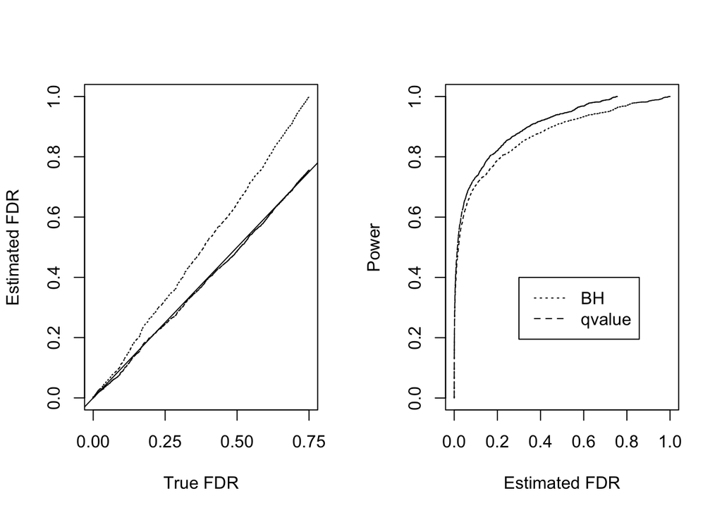

```r
par(mfrow=c(1,2))
plot(ntt$FDR,ntt$BH.adjp,type="s",xlab="True FDR",ylab="Estimated FDR",lty=3,xlim=c(0,0.75),axes=F)
axis(1,at=c(0,.25,.5,.75))
axis(2)
box()
lines(ntt$FDR,ntt$qvalue,type="s",lty=2)
#legend(0,1,c("BH","qvalue"),lty=c(2,3))
abline(0,1)

plot(ntt$BH.adjp,ntt$pwr,type="s",xlab="Estimated FDR",
    ylab="Power",lty=3)
lines(ntt$qvalue,ntt$pwr,type="s",lty=2)
legend(.3,.4,c("BH","qvalue"),lty=c(3,2))
```

The BH adjusted pvalue overestimates the true FDR and the q-value appears unbiased.

## 1,000 Data sets ($\pi_0=75\%$; **G=10,000**)

Now let’s run this 1000 times, and summarize.

```r
set.seed(3214)
nsim=1000
BH5p.out= cbind.data.frame(TP = rep(NA,nsim),
                           FP = rep(NA,nsim),
                           FDR = rep(NA,nsim),
                           Power = rep(NA,nsim))
BH20p.out=BH5p.out
q5p.out=cbind.data.frame(BH5p.out,pi0=rep(NA,nsim))
q20p.out=q5p.out

for (j in 1:nsim) {
  sim <- simdat(ssds,delta=0.11)
  tt=rowttests(sim$E,sim$targets)
    BH.adjp=p.adjust(tt$p.value,method="BH")
    qobj=qvalue(tt$p.value)

    BH5p.out[j,]=unlist(est.error(ifelse(BH.adjp<0.05,1,0),sim$genes))
    q5p.out[j,]=c(unlist(est.error(ifelse(qobj$qvalues<0.05,1,0),
                                   sim$genes)),
                      qobj$pi0)
    BH20p.out[j,]=unlist(est.error(ifelse(BH.adjp<0.2,1,0),sim$genes))
    q20p.out[j,]=c(unlist(est.error(ifelse(qobj$qvalues<0.2,1,0),sim$genes)),
            qobj$pi0)
}
```

Summarize the mean and 95% confidence interval limits for the 5% and 20% FDR estimates (BH adjusted p & qvalue methods).

```r
BH05.sum<- BH5p.out %>%
            summarize(mfdr = mean(FDR),
                      lbfdr = quantile(FDR,0.05),
                      ubfdr = quantile(FDR,0.95),
                      mpwr = mean(Power),
                      lbpwr = quantile(Power,0.05),
                      ubpwr = quantile(Power,0.95))
q05.sum<- q5p.out %>%
            summarize(mfdr = mean(FDR),
                      lbfdr = quantile(FDR,0.05),
                      ubfdr = quantile(FDR,0.95),
                      mpwr = mean(Power),
                      lbpwr = quantile(Power,0.05),
                      ubpwr = quantile(Power,0.95))
BH20.sum<- BH20p.out %>%
            summarize(mfdr = mean(FDR),
                      lbfdr = quantile(FDR,0.05),
                      ubfdr = quantile(FDR,0.95),
                      mpwr = mean(Power),
                      lbpwr = quantile(Power,0.05),
                      ubpwr = quantile(Power,0.95))
q20.sum<- q20p.out %>%
            summarize(mfdr = mean(FDR),
                      lbfdr = quantile(FDR,0.05),
                      ubfdr = quantile(FDR,0.95),
                      mpwr = mean(Power),
                      lbpwr = quantile(Power,0.05),
                      ubpwr = quantile(Power,0.95))
tabrslts<- rbind.data.frame(cbind.data.frame(method="bh05",row=1,BH05.sum),
                         cbind.data.frame(method="q05",row=2,q05.sum),
                         cbind.data.frame(method="bh20",row=3,BH20.sum),
                         cbind.data.frame(method="q20",row=4,q20.sum))
tabrslts
```

```
##   method row       mfdr      lbfdr      ubfdr      mpwr  lbpwr   ubpwr
## 1   bh05   1 0.03771214 0.02937247 0.04617570 0.5953516 0.5780 0.61202
## 2    q05   2 0.04958092 0.04004802 0.05909903 0.6299824 0.6124 0.64800
## 3   bh20   3 0.14981666 0.13712258 0.16241417 0.7748608 0.7604 0.78842
## 4    q20   4 0.19707590 0.17795071 0.21539777 0.8111256 0.7960 0.82560
```

The 3.5% increase in power for a q < 0.05 results in 87 more true discoveries (=0.035*2500).

Here’s the estimate of $\pi_0$.

```r
q20p.out %>%
            summarize(mpi0 = mean(pi0),
                      lbpi0 = quantile(pi0,0.05),
                      ubpi0 = quantile(pi0,0.95))
```

```
##        mpi0     lbpi0     ubpi0
## 1 0.7610531 0.7202409 0.8051377
```

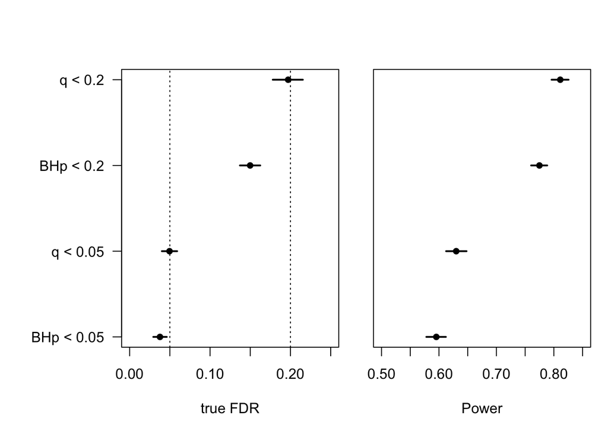

```r
par(mfrow=c(1,2),oma=c(1,5,1,1),mar=c(4,2,3,0))
plot(tabrslts[,"mfdr"],c(1:4),xlim=c(0,0.25),pch=16,
     xlab="true FDR",ylab="",axes=F)
segments(tabrslts[,"lbfdr"],c(1:4),tabrslts[,"ubfdr"],c(1:4),lwd=2)
abline(v=0.05,lty=3)
abline(v=0.2,lty=3)
box(); axis(1); axis(2,at=c(1:4), c("BHp < 0.05","q < 0.05","BHp < 0.2","q < 0.2"),las=2)
plot(tabrslts[,"mpwr"],c(1:4),xlim=c(0.5,0.85),pch=16,
     xlab="Power",ylab="",axes=F)
segments(tabrslts[,"lbpwr"],c(1:4),tabrslts[,"ubpwr"],c(1:4),lwd=2)
box(); axis(1)
```

Yes, we see the qvalue is unbiased for estimating the FDR, whereas the BH adjusted pvalue is conservative. This small difference translates into slighly higher power using the q-value approach.

## 1 Data set ($\pi_0 = 99\%, 75\%, 50\%$)

```r
set.seed(210)  # This sets a reproducible starting point
              # for our random number generator

sim1 <- simdat(ssds,delta=0.11,pi0=0.99)
tt=rowttests(sim1$E,sim1$targets)
qobj=qvalue(tt$p.value)
tt99 <- tt %>%
        mutate(BH.adjp=p.adjust(tt$p.value,method="BH"),
                 qvalue=qobj$qvalue,
                 truedeg = sim1$genes,
                 nullgene = 1-sim1$genes,
                 n = 1)

sim1 <- simdat(ssds,delta=0.11,pi0=0.75)
tt=rowttests(sim1$E,sim1$targets)
qobj=qvalue(tt$p.value)
tt75 <- tt %>%
        mutate(BH.adjp=p.adjust(tt$p.value,method="BH"),
                 qvalue=qobj$qvalue,
                 truedeg = sim1$genes,
                 nullgene = 1-sim1$genes,
                 n = 1)

sim1 <- simdat(ssds,delta=0.11,pi0=0.50)
tt=rowttests(sim1$E,sim1$targets)
qobj=qvalue(tt$p.value)
tt50 <- tt %>%
        mutate(BH.adjp=p.adjust(tt$p.value,method="BH"),
                 qvalue=qobj$qvalue,
                 truedeg = sim1$genes,
                 nullgene = 1-sim1$genes,
                 n = 1)
```

```r
ntt99 <- tt99 %>%
       arrange(p.value)  %>%
        select(BH.adjp,qvalue,truedeg,nullgene,n) %>%
        mutate(n_tp = cumsum(truedeg),
               n_fd = cumsum(nullgene),
               n_t  = cumsum(n))   %>%
        group_by(BH.adjp)  %>%
          slice(which.max(n_t)) %>%
       mutate( FDR = n_fd/n_t,
               pwr = n_tp/ng/(1-pinull))

ntt75 <- tt75 %>%
       arrange(p.value)  %>%
        select(BH.adjp,qvalue,truedeg,nullgene,n) %>%
        mutate(n_tp = cumsum(truedeg),
               n_fd = cumsum(nullgene),
               n_t  = cumsum(n))   %>%
        group_by(BH.adjp)  %>%
          slice(which.max(n_t)) %>%
       mutate( FDR = n_fd/n_t,
               pwr = n_tp/ng/(1-pinull))

ntt50 <- tt50 %>%
       arrange(p.value)  %>%
        select(BH.adjp,qvalue,truedeg,nullgene,n) %>%
        mutate(n_tp = cumsum(truedeg),
               n_fd = cumsum(nullgene),
               n_t  = cumsum(n))   %>%
        group_by(BH.adjp)  %>%
          slice(which.max(n_t)) %>%
       mutate( FDR = n_fd/n_t,
               pwr = n_tp/ng/(1-pinull))
```

Plot the results.

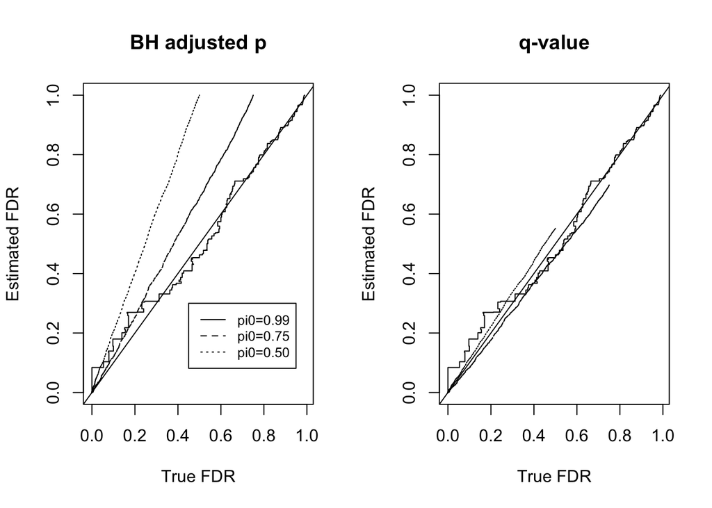

```r
par(mfrow=c(1,2))
plot(ntt99$FDR,ntt99$BH.adjp,type="s",main="BH adjusted p",xlab="True FDR",ylab="Estimated FDR",lty=1)
lines(ntt75$FDR,ntt75$BH.adjp,type="s",lty=2)
lines(ntt50$FDR,ntt50$BH.adjp,type="s",lty=3)
legend(.45,.3,c("pi0=0.99","pi0=0.75","pi0=0.50"),lty=c(1:3),cex=.8)
abline(0,1)

plot(ntt99$FDR,ntt99$qvalue,type="s",main="q-value",xlab="True FDR",
    ylab="Estimated FDR",lty=1)
lines(ntt75$FDR,ntt75$qvalue,type="s",lty=2)
lines(ntt50$FDR,ntt50$qvalue,type="s",lty=3)
abline(0,1)
```

The larger $\pi_0$ (closer to 1), the less biased the BH FDR adjusted pvalue as estimates of the true FDR.

Now let’s simulate some data, analyze, and plot the estimated false-discovery rate (FDR) as a function of the true FDR.

```r
set.seed(15)  # This sets a reproducible starting point
              # for our random number generator

sim1 <- simdat(ssds,delta=0.11,ng=200,pi0=0.75)
tt=rowttests(sim1$E,sim1$targets)
qobj=qvalue(tt$p.value)
wtt <- tt %>%
        mutate(BH.adjp=p.adjust(tt$p.value,method="BH"),
                 qvalue=qobj$qvalue,
                 truedeg = sim1$genes,
                 nullgene = 1-sim1$genes,
                 n = 1)
```

Sort the results on the pvalues and count the TPs and FPs.

```r
wtt <- wtt %>%
       arrange(p.value)
ntt <- wtt %>%
        select(BH.adjp,qvalue,truedeg,nullgene,n) %>%
        mutate(n_tp = cumsum(truedeg),
               n_fd = cumsum(nullgene),
               n_t  = cumsum(n))   %>%
        group_by(BH.adjp)  %>%
          slice(which.max(n_t)) %>%
       mutate( FDR = n_fd/n_t,
               pwr = n_tp/ng/(1-pinull))
```

Plot the results.

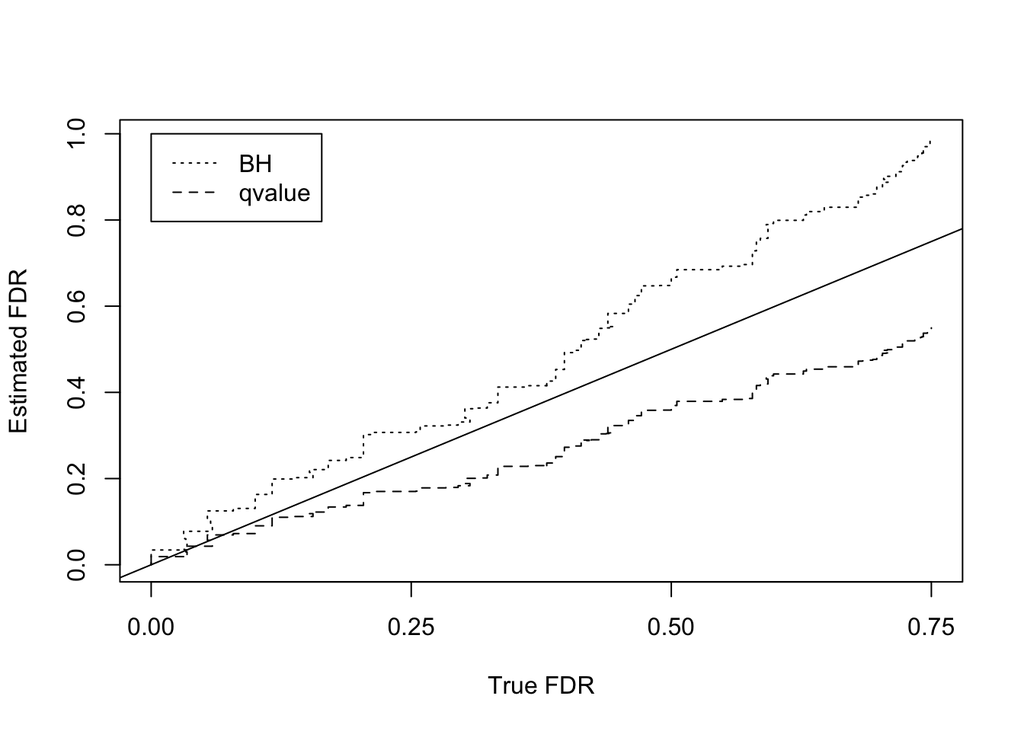

```r
plot(ntt$FDR,ntt$BH.adjp,type="s",xlab="True FDR",ylab="Estimated FDR",lty=3,xlim=c(0,0.75),axes=F)
axis(1,at=c(0,.25,.5,.75))
axis(2)
box()
lines(ntt$FDR,ntt$qvalue,type="s",lty=2)
legend(0,1,c("BH","qvalue"),lty=c(3,2))
abline(0,1)
```

The qvalue underestimates the true FDR in this data set. What about on average?

Now let’s run this 1000 times, and summarize.

```r
nsim=1000
BH5p.out= cbind.data.frame(TP = rep(NA,nsim),
                           FP = rep(NA,nsim),
                           FDR = rep(NA,nsim),
                           Power = rep(NA,nsim))
BH20p.out=BH5p.out
q5p.out=cbind.data.frame(BH5p.out,pi0=rep(NA,nsim))
q20p.out=q5p.out

set.seed(3)
for (j in 1:nsim) {
  sim <- simdat(ssds,delta=0.11,ng=200,pi0=0.75)
  tt=rowttests(sim$E,sim$targets)
    BH.adjp=p.adjust(tt$p.value,method="BH")
    qobj=qvalue(tt$p.value)

    BH5p.out[j,]=unlist(est.error(ifelse(BH.adjp<0.05,1,0),sim$genes))
    q5p.out[j,]=c(unlist(est.error(ifelse(qobj$qvalues<0.05,1,0),
                                   sim$genes)),
                      qobj$pi0)
    BH20p.out[j,]=unlist(est.error(ifelse(BH.adjp<0.2,1,0),sim$genes))
    q20p.out[j,]=c(unlist(est.error(ifelse(qobj$qvalues<0.2,1,0),sim$genes)),
            qobj$pi0)
}
```

```r
BH05.sum<- BH5p.out %>%
            summarize(mfdr = mean(FDR),
                      lbfdr = quantile(FDR,0.05),
                      ubfdr = quantile(FDR,0.95),
                      mpwr = mean(Power),
                      lbpwr = quantile(Power,0.05),
                      ubpwr = quantile(Power,0.95))
q05.sum<- q5p.out %>%
            summarize(mfdr = mean(FDR),
                      lbfdr = quantile(FDR,0.05),
                      ubfdr = quantile(FDR,0.95),
                      mpwr = mean(Power),
                      lbpwr = quantile(Power,0.05),
                      ubpwr = quantile(Power,0.95))
BH20.sum<- BH20p.out %>%
            summarize(mfdr = mean(FDR),
                      lbfdr = quantile(FDR,0.05),
                      ubfdr = quantile(FDR,0.95),
                      mpwr = mean(Power),
                      lbpwr = quantile(Power,0.05),
                      ubpwr = quantile(Power,0.95))
q20.sum<- q20p.out %>%
            summarize(mfdr = mean(FDR),
                      lbfdr = quantile(FDR,0.05),
                      ubfdr = quantile(FDR,0.95),
                      mpwr = mean(Power),
                      lbpwr = quantile(Power,0.05),
                      ubpwr = quantile(Power,0.95))
tabrslts<- rbind.data.frame(cbind.data.frame(method="bh05",row=1,BH05.sum),
                         cbind.data.frame(method="q05",row=2,q05.sum),
                         cbind.data.frame(method="bh20",row=3,BH20.sum),
                         cbind.data.frame(method="q20",row=4,q20.sum))
tabrslts
```

```
##   method row       mfdr      lbfdr     ubfdr    mpwr lbpwr ubpwr
## 1   bh05   1 0.03656369 0.00000000 0.1000000 0.60102  0.48  0.72
## 2    q05   2 0.05155802 0.00000000 0.1251330 0.64030  0.52  0.76
## 3   bh20   3 0.14653340 0.05398293 0.2374237 0.78184  0.68  0.86
## 4    q20   4 0.20659597 0.08333333 0.3522490 0.82132  0.72  0.92
```

```r
q20p.out %>%
            summarize(mpi0 = mean(pi0),
                      lbpi0 = quantile(pi0,0.05),
                      ubpi0 = quantile(pi0,0.95))
```

```
##        mpi0     lbpi0 ubpi0
## 1 0.7561154 0.4814967     1
```

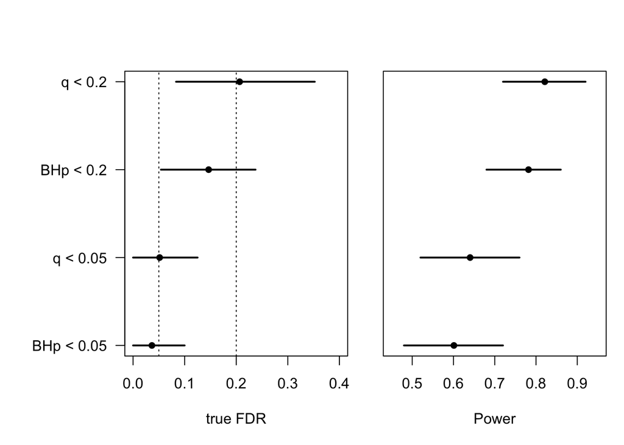

```r
par(mfrow=c(1,2),oma=c(1,5,1,1),mar=c(4,2,3,0))
plot(tabrslts[,"mfdr"],c(1:4),xlim=c(0,0.4),pch=16,
     xlab="true FDR",ylab="",axes=F)
segments(tabrslts[,"lbfdr"],c(1:4),tabrslts[,"ubfdr"],c(1:4),lwd=2)
abline(v=0.05,lty=3)
abline(v=0.2,lty=3)
box(); axis(1); axis(2,at=c(1:4), c("BHp < 0.05","q < 0.05","BHp < 0.2","q < 0.2"),las=2)
plot(tabrslts[,"mpwr"],c(1:4),xlim=c(0.45,0.95),pch=16,
     xlab="Power",ylab="",axes=F)
segments(tabrslts[,"lbpwr"],c(1:4),tabrslts[,"ubpwr"],c(1:4),lwd=2)
box(); axis(1)
```

On average, the q-value is unbiased. However, the confidence interval is huge. This is because the number of tests is too small. Storey and Tibshirani recommend a minimum of 3,000 tests before using the q-value as an FDR estimate.